# TD_Reg

ISLA Thomas

11/12/2020

# TD Régression Linéaire Multiple

## Observations des données

```r
library(MASS)
head(Boston)
```

```
##      crim zn indus chas   nox    rm  age    dis rad tax ptratio  black lstat
## 1 0.00632 18  2.31    0 0.538 6.575 65.2 4.0900   1 296    15.3 396.90  4.98
## 2 0.02731  0  7.07    0 0.469 6.421 78.9 4.9671   2 242    17.8 396.90  9.14
## 3 0.02729  0  7.07    0 0.469 7.185 61.1 4.9671   2 242    17.8 392.83  4.03
## 4 0.03237  0  2.18    0 0.458 6.998 45.8 6.0622   3 222    18.7 394.63  2.94
## 5 0.06905  0  2.18    0 0.458 7.147 54.2 6.0622   3 222    18.7 396.90  5.33
## 6 0.02985  0  2.18    0 0.458 6.430 58.7 6.0622   3 222    18.7 394.12  5.21
##   medv
## 1 24.0
## 2 21.6
## 3 34.7
## 4 33.4
## 5 36.2
## 6 28.7
```

```r
str(Boston)
```

```
## 'data.frame':    506 obs. of  14 variables:
##  $ crim   : num  0.00632 0.02731 0.02729 0.03237 0.06905 ...
##  $ zn     : num  18 0 0 0 0 0 12.5 12.5 12.5 12.5 ...
##  $ indus  : num  2.31 7.07 7.07 2.18 2.18 2.18 7.87 7.87 7.87 7.87 ...
##  $ chas   : int  0 0 0 0 0 0 0 0 0 0 ...
##  $ nox    : num  0.538 0.469 0.469 0.458 0.458 0.458 0.524 0.524 0.524 0.524 ...
##  $ rm     : num  6.58 6.42 7.18 7 7.15 ...
##  $ age    : num  65.2 78.9 61.1 45.8 54.2 58.7 66.6 96.1 100 85.9 ...
##  $ dis    : num  4.09 4.97 4.97 6.06 6.06 ...
##  $ rad    : int  1 2 2 3 3 3 5 5 5 5 ...
##  $ tax    : num  296 242 242 222 222 222 311 311 311 311 ...
##  $ ptratio: num  15.3 17.8 17.8 18.7 18.7 18.7 15.2 15.2 15.2 15.2 ...
##  $ black  : num  397 397 393 395 397 ...
##  $ lstat  : num  4.98 9.14 4.03 2.94 5.33 ...
##  $ medv   : num  24 21.6 34.7 33.4 36.2 28.7 22.9 27.1 16.5 18.9 ...
```

Deux facteurs, ou variables qualitatives, “Chas” pour la proximité ou non de la rivière et “rad” qui est une évaluation de l’accesibilité aux autoroutes.

Observons les variables quantitatives tout d’abord.

```r
library(caret)
Boston_Quanti=Boston[,-c(4,9)]
```

```r
library(psych)
```

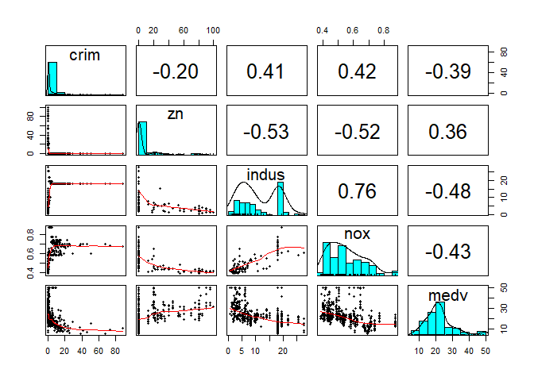

```r
pairs.panels(Boston_Quanti[,c(1:4,12)],ellipses = FALSE)
```

Plusieurs remarques :

- Indus et Nox ont l’air plutôt corrélés, il faudrait être attentif. La corrélation est logique puisque Indus représente les entreprises et Nox la concentration NO.
- Indux et Nox ont la plus grande corrélation avec la réponse.
- Crim et Zn présentent des outliers important. A reconfirmer.

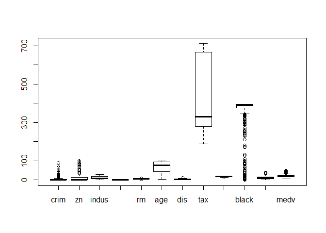

```r
boxplot(Boston_Quanti)
```

Pas une bonne observation.

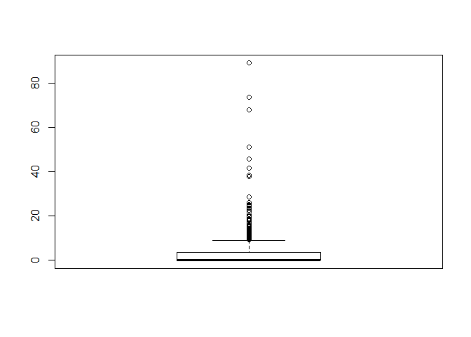

```r
boxplot(Boston_Quanti[1])
```

Comme pressentit on a enormément d’outliers, cependant dur de les supprimer car important pour l’explication de la réponse.

Si on supprime les outliers est-ce qu’on améliorer la corrélation avec la réponse?

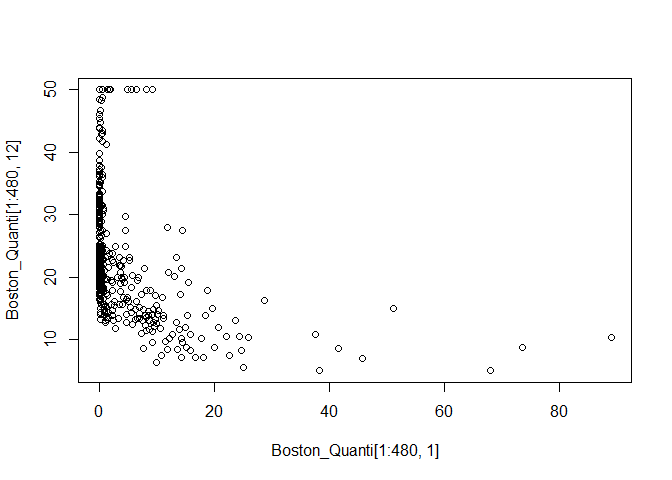

```r
plot(Boston_Quanti[1:480,1],Boston_Quanti[1:480,12])
```

```r
cor(Boston_Quanti[1:480,1],Boston_Quanti[1:480,12])
```

```
## [1] -0.4005788
```

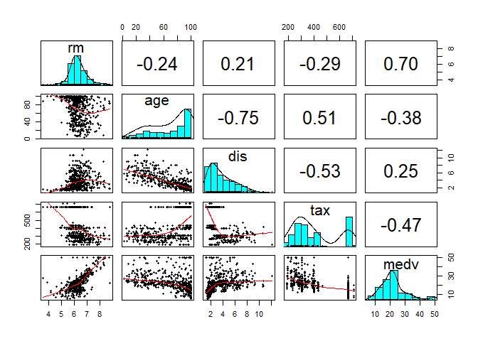

```r
pairs.panels(Boston_Quanti[,c(5:8,12)],ellipses = FALSE)
```

Rm est un bon choix de variables. Forte corrélation entre Dis et Age qui est logique, les jeunes sont plus enclin à parcourir des longues distances pour travailler.

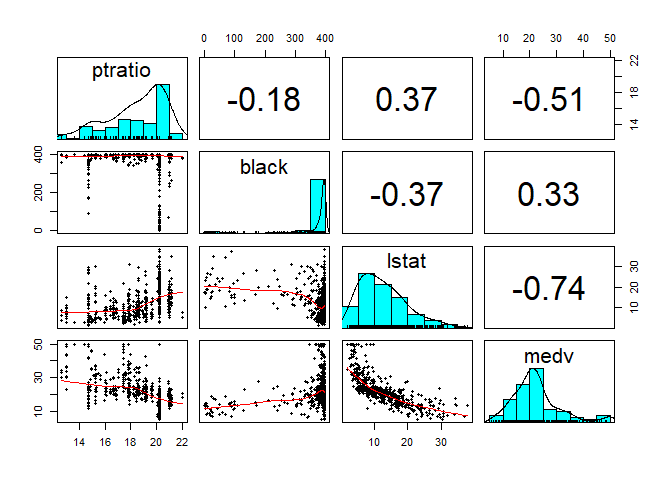

```r
pairs.panels(Boston_Quanti[,c(9:12)],ellipses = FALSE)
```

La variable Lstat est fortement corrélé à notre réponse.

## Début du TD

```r
library(caTools)
set.seed(55)
split=sample.split(Boston$medv,SplitRatio = 0.70)
```

```r
train=Boston[split==TRUE,]
test=Boston[split==FALSE,]
```

# On s’intéresse à la variable Age

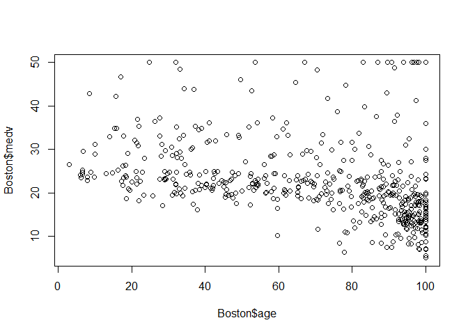

```r
plot(Boston$age,Boston$medv)
```

```r
cor(Boston$age,Boston$medv)
```

```
## [1] -0.3769546
```

On est face à une corrélation assez faible.

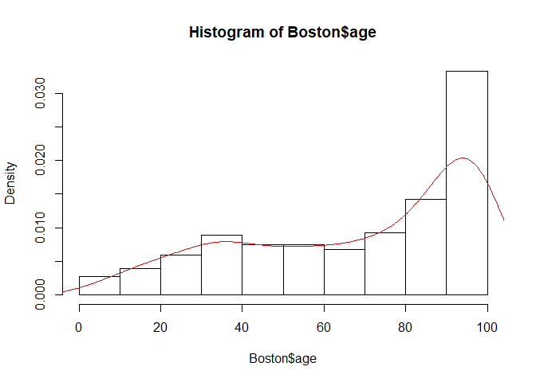

```r
hist(Boston$age,freq = FALSE)
lines(density(Boston_Quanti$age),col='red')
```

On est pas vraiment sur une distribution normale ici, même si le TCL nous permet d’utiliser la variable.

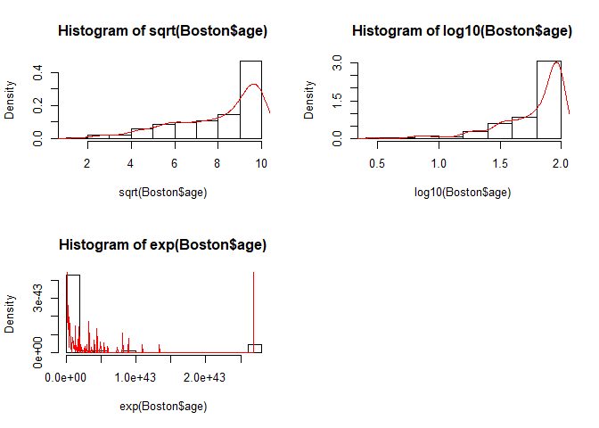

```r
par(mfrow=c(2,2))
hist(sqrt(Boston$age),freq = FALSE)
lines(density(sqrt(Boston_Quanti$age)),col='red')
hist(log10(Boston$age),freq = FALSE)
lines(density(log10(Boston_Quanti$age)),col='red')
hist(exp(Boston$age),freq = FALSE)
lines(density(exp(Boston_Quanti$age)),col='red')
```

Cela semble compliquer de d’améliorer l’allure de la courbe.

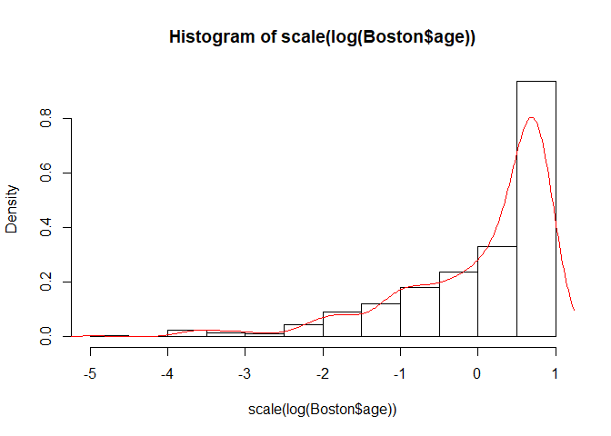

```r
hist(scale(log(Boston$age)),freq = FALSE)
lines(density(scale(log(Boston_Quanti$age))),col='red')
```

# On réalise le modèle

```r
m1=lm(medv~age,data = train,)
train_Age_Scale=train
train_Age_Scale["age"]=scale(train_Age_Scale["age"])
m1_scale=lm(medv~age,data = train_Age_Scale,)
```

```r
summary(m1)
```

```
##
## Call:
## lm(formula = medv ~ age, data = train)
##
## Residuals:
##     Min      1Q  Median      3Q     Max
## -15.343  -5.425  -1.917   2.207  31.362
##
## Coefficients:
##             Estimate Std. Error t value Pr(>|t|)
## (Intercept)  32.1752     1.1776  27.322  < 2e-16 ***
## age          -0.1354     0.0160  -8.463  6.4e-16 ***
## ---
## Signif. codes:  0 '***' 0.001 '**' 0.01 '*' 0.05 '.' 0.1 ' ' 1
##
## Residual standard error: 8.679 on 365 degrees of freedom
## Multiple R-squared:  0.164,  Adjusted R-squared:  0.1617
## F-statistic: 71.62 on 1 and 365 DF,  p-value: 6.398e-16
```

La variable Age est statistiquement pertinente, le modèle est pertinent également au vu de la statistque de Fisher. Le R est de 16% donc pas le modèle n’explique qu’une petite part de la variance totale.

```r
summary(m1_scale)
```

```
##
## Call:
## lm(formula = medv ~ age, data = train_Age_Scale)
##
## Residuals:
##     Min      1Q  Median      3Q     Max
## -15.343  -5.425  -1.917   2.207  31.362
##
## Coefficients:
##             Estimate Std. Error t value Pr(>|t|)
## (Intercept)  22.9757     0.4530  50.715  < 2e-16 ***
## age          -3.8394     0.4537  -8.463  6.4e-16 ***
## ---
## Signif. codes:  0 '***' 0.001 '**' 0.01 '*' 0.05 '.' 0.1 ' ' 1
##
## Residual standard error: 8.679 on 365 degrees of freedom
## Multiple R-squared:  0.164,  Adjusted R-squared:  0.1617
## F-statistic: 71.62 on 1 and 365 DF,  p-value: 6.398e-16
```

Identique logique.

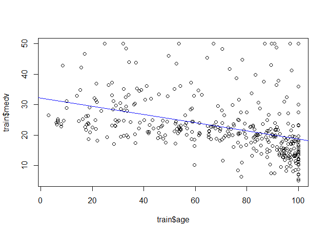

```r
plot(train$age,train$medv)
abline(m1,col='blue')
```

# On s’intéresse aux variables Age et Lstat

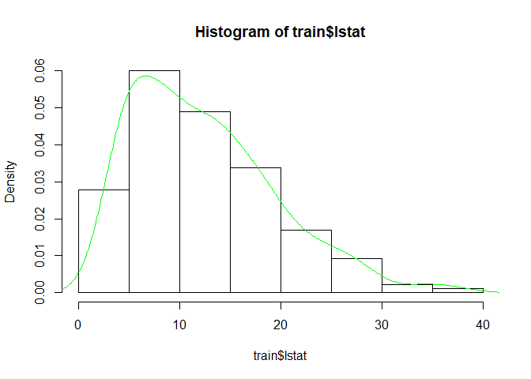

```r
hist(train$lstat,freq = FALSE)
lines(density(train$lstat),col='green')
```

On est assez proche d’une loi normale, comme demandé par les hyp de la régréssion.

```r
shapiro.test(train$lstat)
```

```
##
##  Shapiro-Wilk normality test
##
## data:  train$lstat
## W = 0.93767, p-value = 2.798e-11
```

Ici on rejette l’hypothèse nulle donc l’échantillon ne suit pas une loi normale.

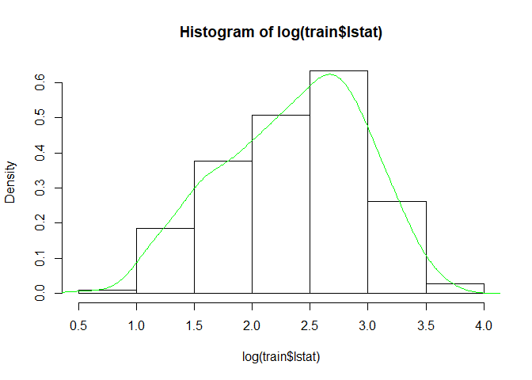

```r
hist(log(train$lstat),freq = FALSE)
lines(density(log(train$lstat)),col='green')
```

```r
shapiro.test(log(train$lstat))
```

```
##
##  Shapiro-Wilk normality test
##
## data:  log(train$lstat)
## W = 0.98233, p-value = 0.0001809
```

Statistiquement l’échantillon ne suit pas une loi normale, mais dans la pratique on l’utilise. Par curiosité on a essayé de scaler et mauvais résultat.

# On réalise notre modelè :

```r
lm2=lm(medv~age+log(lstat),data = train)
summary(lm2)
```

```
##
## Call:
## lm(formula = medv ~ age + log(lstat), data = train)
##
## Residuals:
##      Min       1Q   Median       3Q      Max
## -13.6035  -3.3231  -0.8358   2.3126  23.3453
##
## Coefficients:
##              Estimate Std. Error t value Pr(>|t|)
## (Intercept)  53.02081    1.09472  48.433  < 2e-16 ***
## age           0.06995    0.01268   5.516 6.58e-08 ***
## log(lstat)  -14.79792    0.58939 -25.107  < 2e-16 ***
## ---
## Signif. codes:  0 '***' 0.001 '**' 0.01 '*' 0.05 '.' 0.1 ' ' 1
##
## Residual standard error: 5.258 on 364 degrees of freedom
## Multiple R-squared:  0.694,  Adjusted R-squared:  0.6923
## F-statistic: 412.7 on 2 and 364 DF,  p-value: < 2.2e-16
```

La variable lstat est très pertinente, dans ce modèle la variable age est moins pertinente que dans le précédent. Logique car la corrélation entre Age et la réponse est assez faible donc on s’attend à ce qu’elle perde en importance à mesure que l’on ajoute des variables plus pertinentes.

```r
rgl::plot3d(log(Boston$lstat),
            Boston$age,
            Boston$medv, type = "p",
            xlab = "log(lstat)",
            ylab = "age",
            zlab = "medv", site = 5, lwd = 15)


rgl::planes3d(lm2$coefficients["log(lstat)"],
              lm2$coefficients["age"], -1,
              lm2$coefficients["(Intercept)"], alpha = 0.3, front = "line")
```

Si on scale les données a-t-on un meilleur résultat?

```r
train_m2_scale=train[,c("age","lstat","medv")]
train_m2_scale[,1:2]=scale(train_m2_scale[,1:2])

lm2_scale=lm(medv~age+log(lstat),data = train)
summary(lm2_scale)
```

```
##
## Call:
## lm(formula = medv ~ age + log(lstat), data = train)
##
## Residuals:
##      Min       1Q   Median       3Q      Max
## -13.6035  -3.3231  -0.8358   2.3126  23.3453
##
## Coefficients:
##              Estimate Std. Error t value Pr(>|t|)
## (Intercept)  53.02081    1.09472  48.433  < 2e-16 ***
## age           0.06995    0.01268   5.516 6.58e-08 ***
## log(lstat)  -14.79792    0.58939 -25.107  < 2e-16 ***
## ---
## Signif. codes:  0 '***' 0.001 '**' 0.01 '*' 0.05 '.' 0.1 ' ' 1
##
## Residual standard error: 5.258 on 364 degrees of freedom
## Multiple R-squared:  0.694,  Adjusted R-squared:  0.6923
## F-statistic: 412.7 on 2 and 364 DF,  p-value: < 2.2e-16
```

# On s’intérésse à l’ensemble des variables

```r
lm_all=lm(medv~.,data=train)
summary(lm_all)
```

```
##
## Call:
## lm(formula = medv ~ ., data = train)
##
## Residuals:
##      Min       1Q   Median       3Q      Max
## -14.4014  -2.8106  -0.4389   1.9124  25.5460
##
## Coefficients:
##               Estimate Std. Error t value Pr(>|t|)
## (Intercept)  39.209365   6.550846   5.985 5.31e-09 ***
## crim         -0.057091   0.046496  -1.228 0.220314
## zn            0.046463   0.015946   2.914 0.003799 **
## indus         0.024273   0.073504   0.330 0.741424
## chas          1.705383   1.070330   1.593 0.111983
## nox         -19.786476   4.794872  -4.127 4.60e-05 ***
## rm            3.722935   0.531314   7.007 1.24e-11 ***
## age           0.010788   0.016272   0.663 0.507774
## dis          -1.516464   0.246678  -6.148 2.13e-09 ***
## rad           0.289813   0.079865   3.629 0.000327 ***
## tax          -0.012073   0.004302  -2.806 0.005292 **
## ptratio      -1.029305   0.171111  -6.015 4.49e-09 ***
## black         0.009908   0.003451   2.871 0.004337 **
## lstat        -0.562686   0.065753  -8.558 3.58e-16 ***
## ---
## Signif. codes:  0 '***' 0.001 '**' 0.01 '*' 0.05 '.' 0.1 ' ' 1
##
## Residual standard error: 4.921 on 353 degrees of freedom
## Multiple R-squared:  0.7401, Adjusted R-squared:  0.7306
## F-statistic: 77.33 on 13 and 353 DF,  p-value: < 2.2e-16
```

Le R s’améliore.

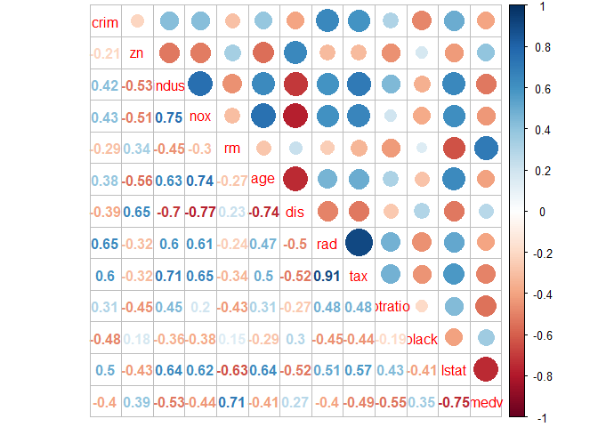

```r
library(corrplot)
corrplot.mixed(cor(train[,c(1,2,3,5,6,7,8,9,10,11,12,13,14)]))
```

```r
lm_all_2=lm(medv~.-tax,data=train)
summary(lm_all_2)
```

```
##
## Call:
## lm(formula = medv ~ . - tax, data = train)
##
## Residuals:
##     Min      1Q  Median      3Q     Max
## -15.085  -3.247  -0.431   1.728  25.650
##
## Coefficients:
##               Estimate Std. Error t value Pr(>|t|)
## (Intercept)  36.821892   6.558128   5.615 3.98e-08 ***
## crim         -0.053690   0.046930  -1.144  0.25338
## zn            0.038265   0.015828   2.418  0.01613 *
## indus        -0.051259   0.069059  -0.742  0.45843
## chas          2.038388   1.074010   1.898  0.05852 .
## nox         -20.974483   4.822298  -4.349 1.79e-05 ***
## rm            3.878577   0.533518   7.270 2.32e-12 ***
## age           0.011507   0.016427   0.700  0.48408
## dis          -1.535967   0.248963  -6.169 1.87e-09 ***
## rad           0.115583   0.050719   2.279  0.02327 *
## ptratio      -1.047586   0.172639  -6.068 3.33e-09 ***
## black         0.010111   0.003484   2.903  0.00393 **
## lstat        -0.563450   0.066388  -8.487 5.88e-16 ***
## ---
## Signif. codes:  0 '***' 0.001 '**' 0.01 '*' 0.05 '.' 0.1 ' ' 1
##
## Residual standard error: 4.968 on 354 degrees of freedom
## Multiple R-squared:  0.7343, Adjusted R-squared:  0.7253
## F-statistic: 81.54 on 12 and 354 DF,  p-value: < 2.2e-16
```

R est certe moins élevé puisque l’on a enlevé un prédicteur mais notre modèle est davantage significatif si l’on regarde F.

```r
prediction=predict(lm_all_2,newdata = test)
MSE=mean((test$medv-prediction)**2)
MSE
```

```
## [1] 19.52441
```

On ne peut pas interpréter ce MSE, il faut le comparer à celui d’un autre modèle.

# Essayons un nouveau modèle sans tax et avec log(lstat)

```r
lm_all_3=lm(medv~.-tax+log(lstat),data = train)
summary(lm_all_3)
```

```
##
## Call:
## lm(formula = medv ~ . - tax + log(lstat), data = train)
##
## Residuals:
##      Min       1Q   Median       3Q      Max
## -14.8092  -2.7270  -0.2251   1.9935  25.1291
##
## Coefficients:
##               Estimate Std. Error t value Pr(>|t|)
## (Intercept)  59.390476   6.341656   9.365  < 2e-16 ***
## crim         -0.124196   0.042677  -2.910  0.00384 **
## zn            0.008227   0.014525   0.566  0.57149
## indus        -0.057205   0.061830  -0.925  0.35550
## chas          1.875588   0.961685   1.950  0.05193 .
## nox         -18.177717   4.327466  -4.201 3.38e-05 ***
## rm            2.428655   0.501849   4.839 1.95e-06 ***
## age           0.039369   0.015001   2.624  0.00906 **
## dis          -1.153496   0.226560  -5.091 5.80e-07 ***
## rad           0.134766   0.045453   2.965  0.00323 **
## ptratio      -0.949233   0.154911  -6.128 2.38e-09 ***
## black         0.009260   0.003120   2.968  0.00320 **
## lstat         0.318576   0.110935   2.872  0.00433 **
## log(lstat)  -12.880628   1.367907  -9.416  < 2e-16 ***
## ---
## Signif. codes:  0 '***' 0.001 '**' 0.01 '*' 0.05 '.' 0.1 ' ' 1
##
## Residual standard error: 4.448 on 353 degrees of freedom
## Multiple R-squared:  0.7877, Adjusted R-squared:  0.7798
## F-statistic: 100.7 on 13 and 353 DF,  p-value: < 2.2e-16
```

Le modèle est plus significatif et explique mieux la variabilité. Pour la variabilité c’est normal puisqu’on rajouter une variable.

```r
prediction1=predict(lm_all_3,newdata = test)
prediction1[1]-log(train$lstat)[1]+train$rad[1]
```

```
##       1
## 33.4251
```

```r
test$medv[1]
```

```
## [1] 24
```

```r
MSE1=mean((test$medv-prediction1)**2)
MSE1
```

```
## [1] 13.27702
```

Demander au prof !

## Anova

```r
aggregate(medv~chas,data=train, FUN=mean)
```

```
##   chas     medv
## 1    0 22.65948
## 2    1 27.49583
```

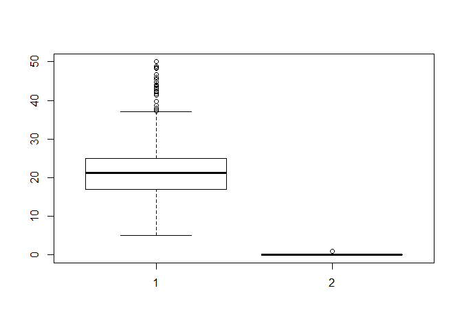

```r
boxplot(Boston$medv,Boston$chas)
```

```r
summary(aov(medv~chas,data=train))
```

```
##              Df Sum Sq Mean Sq F value Pr(>F)
## chas          1    525   524.7   5.917 0.0155 *
## Residuals   365  32364    88.7
## ---
## Signif. codes:  0 '***' 0.001 '**' 0.01 '*' 0.05 '.' 0.1 ' ' 1
```

On rejette l’hypothèse nulle donc les deux variables ont un lien.

```r
train$chas=as.factor(train$chas)
head(train["chas"])
```

```
##   chas
## 2    0
## 3    0
## 4    0
## 5    0
## 6    0
## 7    0
```

```r
lm_quali=lm(medv~chas+crim,data=train)
summary(lm_quali)
```

```
##
## Call:
## lm(formula = medv ~ chas + crim, data = train)
##
## Residuals:
##     Min      1Q  Median      3Q     Max
## -16.136  -5.747  -2.100   3.470  29.998
##
## Coefficients:
##             Estimate Std. Error t value Pr(>|t|)
## (Intercept)  24.3334     0.5111  47.610  < 2e-16 ***
## chas1         4.0207     1.8333   2.193   0.0289 *
## crim         -0.4692     0.0575  -8.160 5.53e-15 ***
## ---
## Signif. codes:  0 '***' 0.001 '**' 0.01 '*' 0.05 '.' 0.1 ' ' 1
##
## Residual standard error: 8.67 on 364 degrees of freedom
## Multiple R-squared:  0.1681, Adjusted R-squared:  0.1635
## F-statistic: 36.78 on 2 and 364 DF,  p-value: 2.826e-15
```

## Séléction

```r
modele_bic=stepAIC(lm_all,direction="both",k=log(length(train$crim)))
```

```
## Start:  AIC=1237.98
## medv ~ crim + zn + indus + chas + nox + rm + age + dis + rad +
##     tax + ptratio + black + lstat
##
##           Df Sum of Sq     RSS    AIC
## - indus    1      2.64  8549.7 1232.2
## - age      1     10.64  8557.7 1232.5
## - crim     1     36.50  8583.6 1233.6
## - chas     1     61.47  8608.5 1234.7
## <none>                  8547.1 1238.0
## - tax      1    190.66  8737.7 1240.2
## - black    1    199.59  8746.6 1240.5
## - zn       1    205.57  8752.6 1240.8
## - rad      1    318.84  8865.9 1245.5
## - nox      1    412.31  8959.4 1249.4
## - ptratio  1    876.14  9423.2 1267.9
## - dis      1    915.05  9462.1 1269.4
## - rm       1   1188.80  9735.9 1279.9
## - lstat    1   1773.15 10320.2 1301.3
##
## Step:  AIC=1232.19
## medv ~ crim + zn + chas + nox + rm + age + dis + rad + tax +
##     ptratio + black + lstat
##
##           Df Sum of Sq     RSS    AIC
## - age      1     10.33  8560.0 1226.7
## - crim     1     37.80  8587.5 1227.9
## - chas     1     63.31  8613.0 1229.0
## <none>                  8549.7 1232.2
## - black    1    198.22  8747.9 1234.7
## - tax      1    201.62  8751.3 1234.8
## - zn       1    204.40  8754.1 1235.0
## + indus    1      2.64  8547.1 1238.0
## - rad      1    322.09  8871.8 1239.9
## - nox      1    429.71  8979.4 1244.3
## - ptratio  1    896.86  9446.6 1262.9
## - dis      1   1006.84  9556.5 1267.1
## - rm       1   1197.01  9746.7 1274.4
## - lstat    1   1771.73 10321.4 1295.4
##
```

[output cut: 43 more lines]

```
##           Df Sum of Sq     RSS    AIC
## <none>                  8664.0 1219.3
## - zn       1    186.26  8850.2 1221.2
## + chas     1     67.74  8596.2 1222.4
## - tax      1    219.89  8883.9 1222.6
## + crim     1     40.70  8623.3 1223.5
## - black    1    274.36  8938.4 1224.9
## + age      1      8.61  8655.4 1224.9
## + indus    1      5.83  8658.2 1225.0
## - rad      1    298.74  8962.7 1225.9
## - nox      1    377.31  9041.3 1229.1
## - ptratio  1    903.85  9567.8 1249.9
## - dis      1   1159.81  9823.8 1259.5
## - rm       1   1355.27 10019.3 1266.8
## - lstat    1   2074.38 10738.4 1292.2
```

```r
modele_bic$coefficients
```

```
##  (Intercept)           zn          nox           rm          dis          rad
##  37.56431556   0.04384300 -17.03169373   3.82837386  -1.56046678   0.25815350
##          tax      ptratio        black        lstat
##  -0.01199150  -1.00892668   0.01121239  -0.56310288
```

```r
library(caret)
train.control=trainControl(method="cv",number=10)
step_model=train(medv~.+I(lstat**2), data = train ,method="leapBackward",
                 tuneGrid=data.frame(nvmax=2:13),
                 trcontrol=train.control)
```

```r
summary(step_model)
```

```
## Subset selection object
## 14 Variables  (and intercept)
##            Forced in Forced out
## crim           FALSE      FALSE
## zn             FALSE      FALSE
## indus          FALSE      FALSE
## chas1          FALSE      FALSE
## nox            FALSE      FALSE
## rm             FALSE      FALSE
## age            FALSE      FALSE
## dis            FALSE      FALSE
## rad            FALSE      FALSE
## tax            FALSE      FALSE
## ptratio        FALSE      FALSE
## black          FALSE      FALSE
## lstat          FALSE      FALSE
## I(lstat^2)     FALSE      FALSE
## 1 subsets of each size up to 13
## Selection Algorithm: backward
##           crim zn  indus chas1 nox rm  age dis rad tax ptratio black lstat
## 1  ( 1 )  " "  " " " "   " "   " " " " " " " " " " " " " "     " "   "*"
## 2  ( 1 )  " "  " " " "   " "   " " "*" " " " " " " " " " "     " "   "*"
## 3  ( 1 )  " "  " " " "   " "   " " "*" " " " " " " " " " "     " "   "*"
## 4  ( 1 )  " "  " " " "   " "   " " "*" " " " " " " " " "*"     " "   "*"
## 5  ( 1 )  " "  " " " "   " "   " " "*" " " "*" " " " " "*"     " "   "*"
## 6  ( 1 )  " "  " " " "   " "   " " "*" " " "*" " " " " "*"     "*"   "*"
## 7  ( 1 )  " "  " " " "   " "   "*" "*" " " "*" " " " " "*"     "*"   "*"
## 8  ( 1 )  " "  " " " "   " "   "*" "*" " " "*" "*" " " "*"     "*"   "*"
## 9  ( 1 )  "*"  " " " "   " "   "*" "*" " " "*" "*" " " "*"     "*"   "*"
## 10  ( 1 ) "*"  " " " "   " "   "*" "*" "*" "*" "*" " " "*"     "*"   "*"
## 11  ( 1 ) "*"  " " " "   " "   "*" "*" "*" "*" "*" "*" "*"     "*"   "*"
## 12  ( 1 ) "*"  " " " "   "*"   "*" "*" "*" "*" "*" "*" "*"     "*"   "*"
## 13  ( 1 ) "*"  "*" " "   "*"   "*" "*" "*" "*" "*" "*" "*"     "*"   "*"
##           I(lstat^2)
## 1  ( 1 )  " "
## 2  ( 1 )  " "
## 3  ( 1 )  "*"
## 4  ( 1 )  "*"
## 5  ( 1 )  "*"
## 6  ( 1 )  "*"
## 7  ( 1 )  "*"
## 8  ( 1 )  "*"
## 9  ( 1 )  "*"
## 10  ( 1 ) "*"
## 11  ( 1 ) "*"
## 12  ( 1 ) "*"
## 13  ( 1 ) "*"
```

```r
step_model$results
```

```
##    nvmax     RMSE  Rsquared      MAE    RMSESD RsquaredSD     MAESD
## 1      2 5.734090 0.6339962 4.062547 0.4149606 0.04343771 0.1873538
## 2      3 5.271692 0.6899931 3.828224 0.4897362 0.05488255 0.1726605
## 3      4 5.133677 0.7058888 3.701950 0.4229413 0.04645861 0.2158001
## 4      5 4.990555 0.7220579 3.605984 0.4397160 0.04700032 0.1754019
## 5      6 4.922753 0.7298485 3.545880 0.3844996 0.03995248 0.1938629
## 6      7 4.929893 0.7293806 3.529180 0.3762908 0.04293673 0.1842279
## 7      8 4.894219 0.7336464 3.517366 0.3747103 0.04171480 0.1657323
## 8      9 4.876467 0.7358113 3.520716 0.3823517 0.04219195 0.1697343
## 9     10 4.847918 0.7395166 3.502097 0.3775562 0.04007772 0.1577784
## 10    11 4.802139 0.7445417 3.462656 0.3862900 0.04009100 0.1641728
## 11    12 4.764537 0.7487685 3.431700 0.3856731 0.03825689 0.1686754
## 12    13 4.725916 0.7525551 3.402013 0.3879636 0.03923646 0.1654067
```

```r
step_model$bestTune
```

```
##    nvmax
## 12    13
```

```r
step_model$finalModel
```

```
## Subset selection object
## 14 Variables  (and intercept)
##            Forced in Forced out
## crim           FALSE      FALSE
## zn             FALSE      FALSE
## indus          FALSE      FALSE
## chas1          FALSE      FALSE
## nox            FALSE      FALSE
## rm             FALSE      FALSE
## age            FALSE      FALSE
## dis            FALSE      FALSE
## rad            FALSE      FALSE
## tax            FALSE      FALSE
## ptratio        FALSE      FALSE
## black          FALSE      FALSE
## lstat          FALSE      FALSE
## I(lstat^2)     FALSE      FALSE
## 1 subsets of each size up to 13
## Selection Algorithm: backward
```

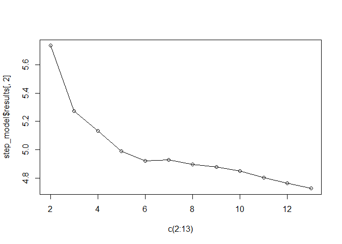

```r
plot(c(2:13),step_model$results[,2],'o')
```

```r
coef(step_model$finalModel,10)
```

```
##   (Intercept)          crim           nox            rm           age
##  44.340805073  -0.125071978 -18.058291034   3.150620797   0.041594665
##           dis           rad       ptratio         black         lstat
##  -1.052870204   0.141858952  -1.016675159   0.008919231  -1.837165272
##    I(lstat^2)
##   0.035756955
```

```r
train$chas=as.factor(train$chas)
a=lm(medv~zn+chas+nox+rm+dis+rad+tax+ptratio+black+lstat,data=train)
summary(a)
```

```
##
## Call:
## lm(formula = medv ~ zn + chas + nox + rm + dis + rad + tax +
##     ptratio + black + lstat, data = train)
##
## Residuals:
##      Min       1Q   Median       3Q      Max
## -14.4879  -2.8815  -0.4159   1.8872  26.2336
##
## Coefficients:
##               Estimate Std. Error t value Pr(>|t|)
## (Intercept)  37.159386   6.381520   5.823 1.29e-08 ***
## zn            0.043597   0.015786   2.762 0.006048 **
## chas1         1.784976   1.065734   1.675 0.094836 .
## nox         -17.784798   4.332038  -4.105 5.01e-05 ***
## rm            3.839633   0.511055   7.513 4.71e-13 ***
## dis          -1.542603   0.225412  -6.843 3.39e-11 ***
## rad           0.250968   0.073519   3.414 0.000715 ***
## tax          -0.011372   0.003991  -2.849 0.004634 **
## ptratio      -0.989901   0.165298  -5.989 5.18e-09 ***
## black         0.011086   0.003327   3.332 0.000953 ***
## lstat        -0.556697   0.060874  -9.145  < 2e-16 ***
## ---
## Signif. codes:  0 '***' 0.001 '**' 0.01 '*' 0.05 '.' 0.1 ' ' 1
##
## Residual standard error: 4.914 on 356 degrees of freedom
## Multiple R-squared:  0.7386, Adjusted R-squared:  0.7313
## F-statistic: 100.6 on 10 and 356 DF,  p-value: < 2.2e-16
```

```r
b=lm(log(medv)~zn+nox+rm+dis+rad+tax+ptratio+black+lstat,data=train)
summary(b)
```

```
##
## Call:
## lm(formula = log(medv) ~ zn + nox + rm + dis + rad + tax + ptratio +
##     black + lstat, data = train)
##
## Residuals:
##      Min       1Q   Median       3Q      Max
## -1.00701 -0.09982 -0.01528  0.09874  0.90473
##
## Coefficients:
##               Estimate Std. Error t value Pr(>|t|)
## (Intercept)  3.9953481  0.2637669  15.147  < 2e-16 ***
## zn           0.0008620  0.0006529   1.320  0.18764
## nox         -0.5860232  0.1782166  -3.288  0.00111 **
## rm           0.0891493  0.0211368   4.218 3.13e-05 ***
## dis         -0.0502652  0.0093132  -5.397 1.24e-07 ***
## rad          0.0074050  0.0030358   2.439  0.01520 *
## tax         -0.0004850  0.0001644  -2.951  0.00338 **
## ptratio     -0.0384813  0.0068210  -5.642 3.43e-08 ***
## black        0.0006429  0.0001376   4.673 4.22e-06 ***
## lstat       -0.0318817  0.0025129 -12.687  < 2e-16 ***
## ---
## Signif. codes:  0 '***' 0.001 '**' 0.01 '*' 0.05 '.' 0.1 ' ' 1
##
## Residual standard error: 0.2033 on 357 degrees of freedom
## Multiple R-squared:  0.7658, Adjusted R-squared:  0.7599
## F-statistic: 129.7 on 9 and 357 DF,  p-value: < 2.2e-16
```

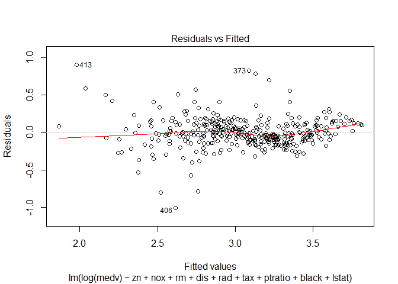

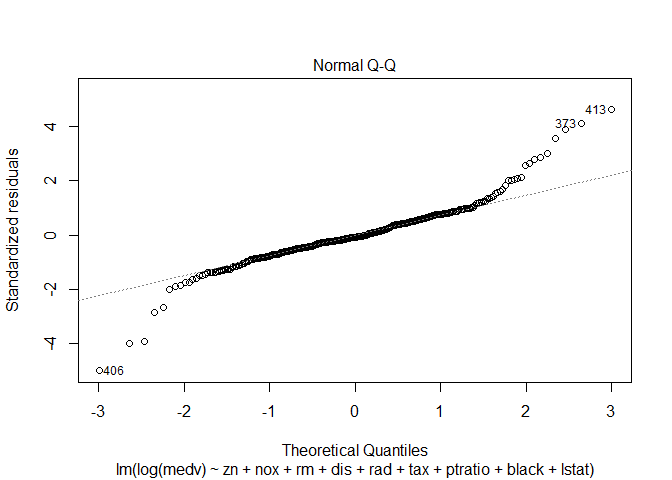

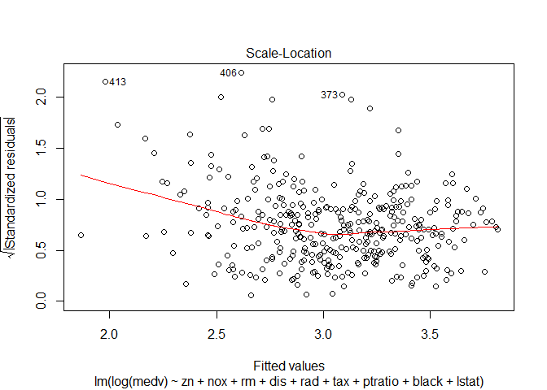

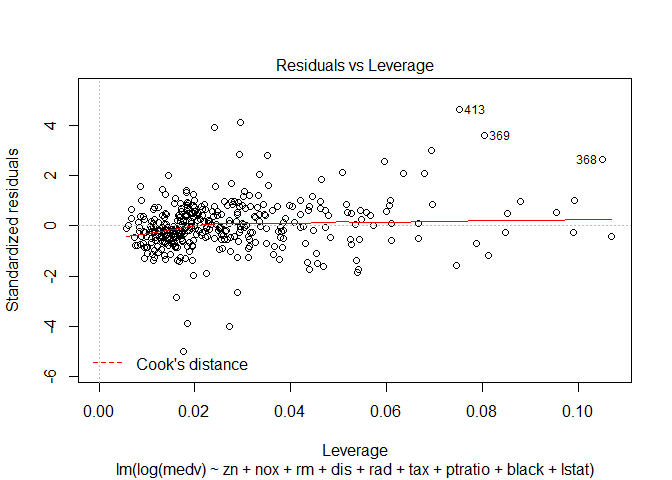

```r
plot(b)
```

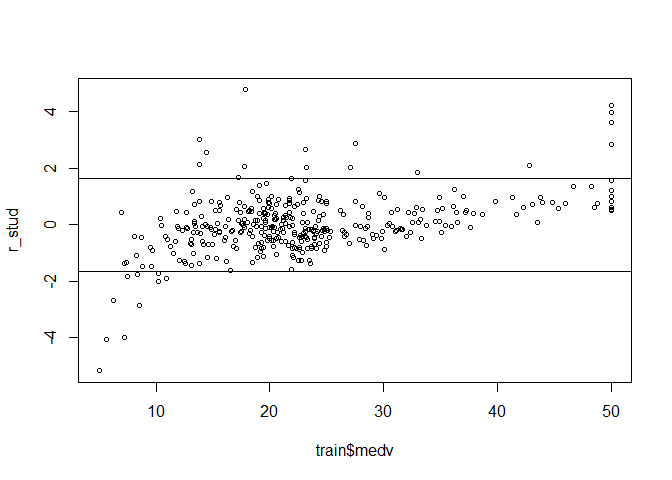

```r
r_stud=rstudent(b)
seuil=qt(1-0.1/2,nrow(train)-3-2)
mask= (r_stud > +seuil | r_stud < -seuil)
valeurs_aberante=train[mask,]
plot(y=r_stud,x=train$medv,cex=0.75)
abline(h=-seuil)
abline(h=seuil)
```

```r
head(valeurs_aberante)
```

```
##         crim   zn indus chas    nox    rm   age    dis rad tax ptratio  black
## 8    0.14455 12.5  7.87    0 0.5240 6.172  96.1 5.9505   5 311    15.2 396.90
## 65   0.01951 17.5  1.38    0 0.4161 7.104  59.5 9.2229   3 216    18.6 393.24
## 142  1.62864  0.0 21.89    0 0.6240 5.019 100.0 1.4394   4 437    21.2 396.90
## 149  2.33099  0.0 19.58    0 0.8710 5.186  93.8 1.5296   5 403    14.7 356.99
## 254  0.36894 22.0  5.86    0 0.4310 8.259   8.4 8.9067   7 330    19.1 396.90
## 368 13.52220  0.0 18.10    0 0.6310 3.863 100.0 1.5106  24 666    20.2 131.42
##     lstat medv
## 8   19.15 27.1
## 65   8.05 33.0
## 142 34.41 14.4
## 149 28.32 17.8
## 254  3.54 42.8
## 368 13.33 23.1
```

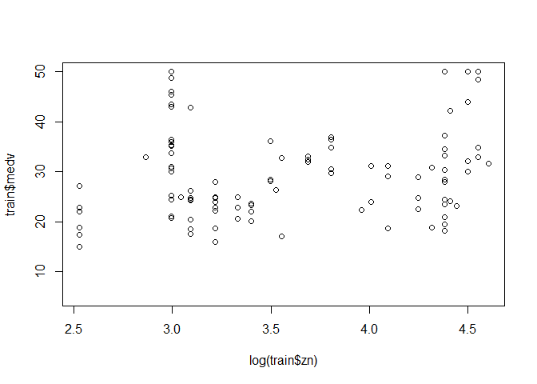

```r
plot(log(train$zn),train$medv)
```

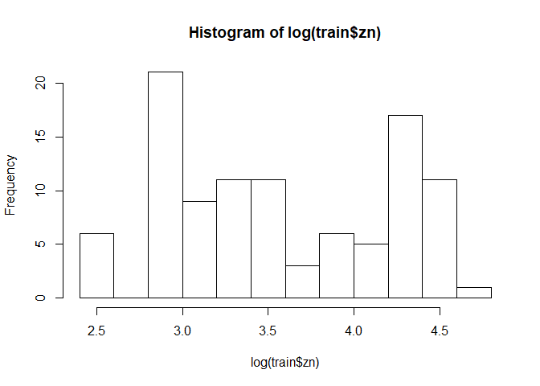

```r
hist(log(train$zn))
```